# CSCI E-63C: Week 4 Q&A session

# Previous homeworks, lectures

Question? Comments? …

# Week 4 homework

go over the examples in preface

# Week 4 quiz

# Statistical significance and predictive quality

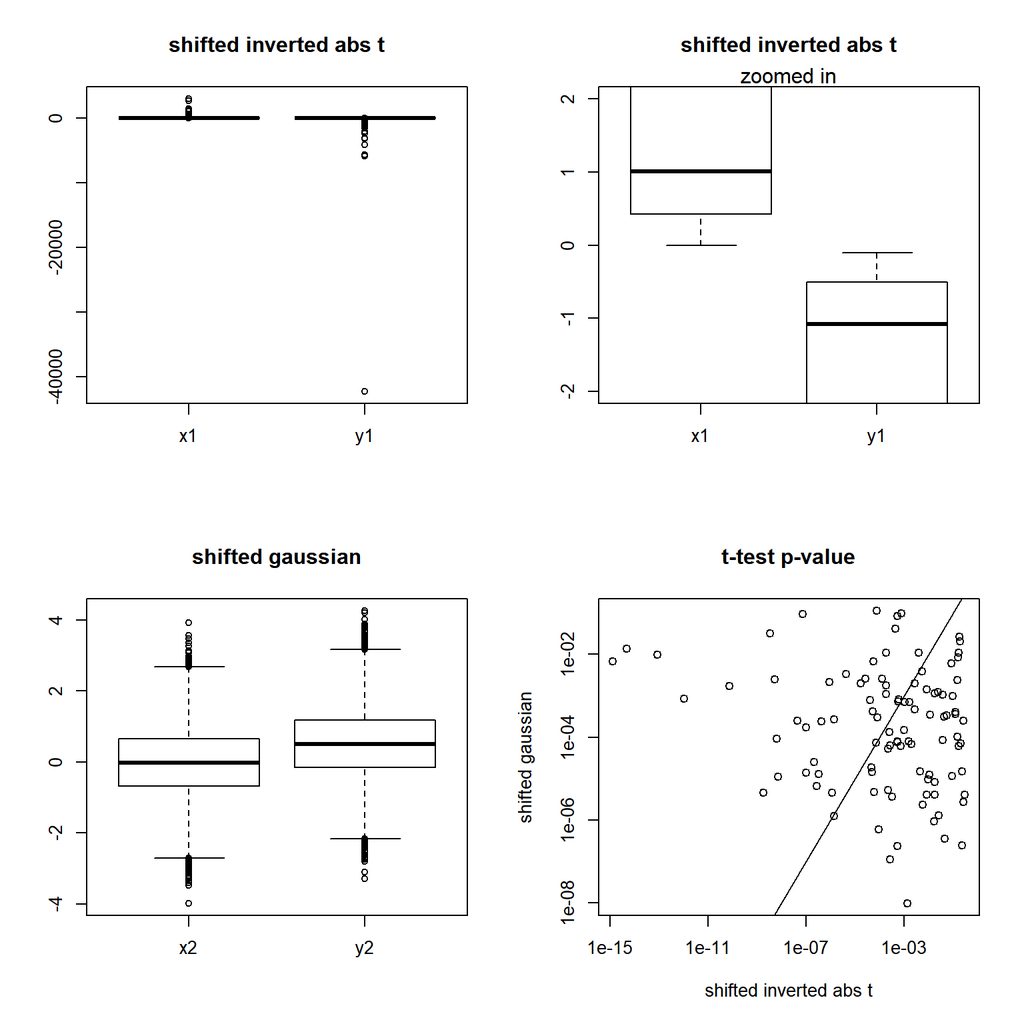

```r
nTmp <- 100
tmp2pvals <- NULL
xyAll <- NULL
for ( iSim in 1:100 ) {
    x1 <- abs(rt(nTmp,1))
    y1 <- -0.1-abs(rt(nTmp,1))
    x2 <- rnorm(nTmp)
    y2 <- 0.5+rnorm(nTmp)
    xyAll <- rbind(xyAll,cbind(x1,y1,x2,y2))
    tmp2pvals <- rbind(tmp2pvals, c(t.test(x1,y1)$p.value,t.test(x2,y2)$p.value))
}
old.par <- par(mfrow=c(2,2))
boxplot(xyAll[,1:2],main="shifted inverted abs t")
boxplot(xyAll[,1:2],main="shifted inverted abs t",ylim=c(-2,2))
mtext("zoomed in")
boxplot(xyAll[,3:4],main="shifted gaussian")
plot(tmp2pvals,log='xy',main="t-test p-value",xlab="shifted inverted abs t",ylab="shifted gaussian")
abline(0,1)
```

```r
par(old.par)
```

In this simulation p-values for a variable allowing for 100% accuracy (shifted inverted absolute of t-distribution with df=1) are often larger than those for a sample from two normal distributions with $\sigma=1$ and $\Delta\mu=0.5$ with corresponding Bayes error rate of about 40%

# ISLR exercises

## Ch.3.7 Ex.14

“This problem focuses on the *collinearity* problem.”

“(a) Perform the following commands in R:”"

```r
set.seed(1)
x1=runif(100)
x2=0.5*x1+rnorm(100)/10
y=2+2*x1+0.3*x2+rnorm(100)
```

“The last line corresponds to creating a linear model in which `y` is a function of `x1` and `x2`. Write out the form of the linear model. What are the regression coefficients?”

“(b) What is the correlation between `x1` and `x2`? Create a scatterplot displaying the relationship between the variables.”

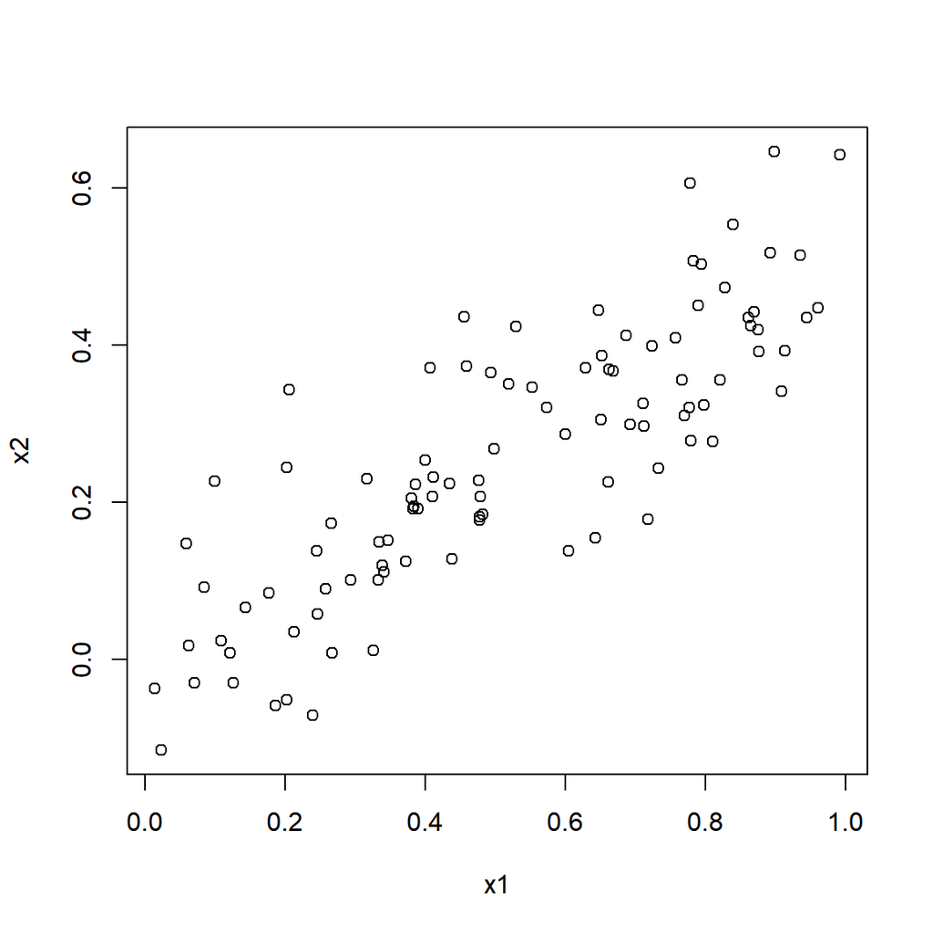

```r
plot(x1,x2)
```

```r
cor(x1,x2)
```

```
## [1] 0.8351212
```

```r
cor(x1,x2,method="spearman")
```

```
## [1] 0.8393399
```

“(c) Using this data, fit a least squares regression to predict `y` using `x1` and `x2`. Describe the results obtained. What are $\hat{\beta}_0$, $\hat{\beta}_1$, and $\hat{\beta}_2$? How do these relate to the true $\beta_0$, $\beta_1$, and $\beta_2$? Can you reject the null hypothesis H0 : $\beta_1 = 0$? How about the null hypothesis H0 : $\beta_2 = 0$?”

```r
lm(y~x1+x2)
```

```
##
## Call:
## lm(formula = y ~ x1 + x2)
##
## Coefficients:
## (Intercept)           x1           x2
##        2.13         1.44         1.01
```

```r
summary(lm(y~x1+x2))
```

```
##
## Call:
## lm(formula = y ~ x1 + x2)
##
## Residuals:
##     Min      1Q  Median      3Q     Max
## -2.8311 -0.7273 -0.0537  0.6338  2.3359
##
## Coefficients:
##             Estimate Std. Error t value Pr(>|t|)
## (Intercept)   2.1305     0.2319   9.188 7.61e-15 ***
## x1            1.4396     0.7212   1.996   0.0487 *
## x2            1.0097     1.1337   0.891   0.3754
## ---
## Signif. codes:  0 '***' 0.001 '**' 0.01 '*' 0.05 '.' 0.1 ' ' 1
##
## Residual standard error: 1.056 on 97 degrees of freedom
## Multiple R-squared:  0.2088, Adjusted R-squared:  0.1925
## F-statistic:  12.8 on 2 and 97 DF,  p-value: 1.164e-05
```

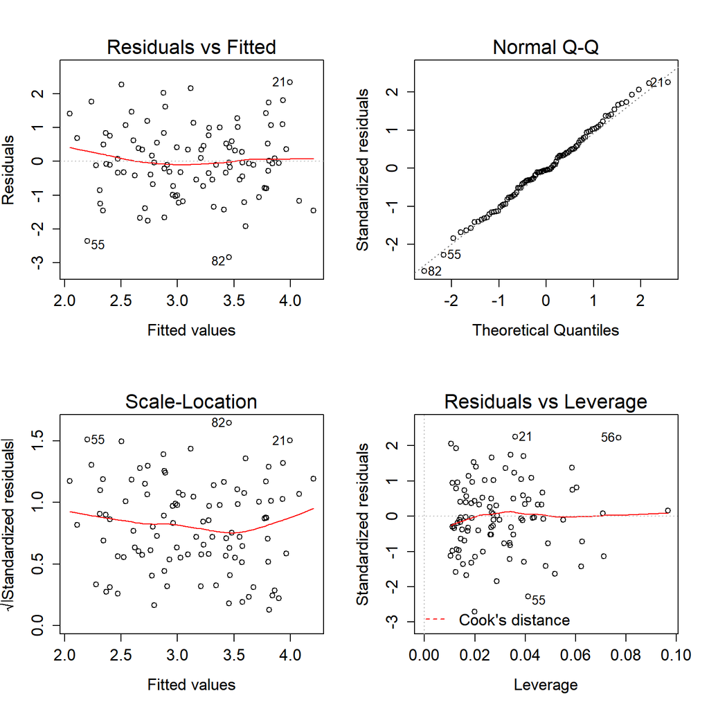

```r
old.par <- par(mfrow=c(2,2),ps=16)
plot(lm(y~x1+x2))
```

```r
par(old.par)
```

“(d) Now fit a least squares regression to predict `y` using only `x1`. Comment on your results. Can you reject the null hypothesis H0 : $\beta_1 = 0$?”

```r
lm(y~x1)
```

```
##
## Call:
## lm(formula = y ~ x1)
##
## Coefficients:
## (Intercept)           x1
##       2.112        1.976
```

```r
summary(lm(y~x1))
```

```
##
## Call:
## lm(formula = y ~ x1)
##
## Residuals:
##      Min       1Q   Median       3Q      Max
## -2.89495 -0.66874 -0.07785  0.59221  2.45560
##
## Coefficients:
##             Estimate Std. Error t value Pr(>|t|)
## (Intercept)   2.1124     0.2307   9.155 8.27e-15 ***
## x1            1.9759     0.3963   4.986 2.66e-06 ***
## ---
## Signif. codes:  0 '***' 0.001 '**' 0.01 '*' 0.05 '.' 0.1 ' ' 1
##
## Residual standard error: 1.055 on 98 degrees of freedom
## Multiple R-squared:  0.2024, Adjusted R-squared:  0.1942
## F-statistic: 24.86 on 1 and 98 DF,  p-value: 2.661e-06
```

“(e) Now fit a least squares regression to predict `y` using only `x2`. Comment on your results. Can you reject the null hypothesis H0 : $\beta_1 = 0$?”

```r
lm(y~x2)
```

```
##
## Call:
## lm(formula = y ~ x2)
##
## Coefficients:
## (Intercept)           x2
##        2.39         2.90
```

```r
summary(lm(y~x2))
```

```
##
## Call:
## lm(formula = y ~ x2)
##
## Residuals:
##      Min       1Q   Median       3Q      Max
## -2.62687 -0.75156 -0.03598  0.72383  2.44890
##
## Coefficients:
##             Estimate Std. Error t value Pr(>|t|)
## (Intercept)   2.3899     0.1949   12.26  < 2e-16 ***
## x2            2.8996     0.6330    4.58 1.37e-05 ***
## ---
## Signif. codes:  0 '***' 0.001 '**' 0.01 '*' 0.05 '.' 0.1 ' ' 1
##
## Residual standard error: 1.072 on 98 degrees of freedom
## Multiple R-squared:  0.1763, Adjusted R-squared:  0.1679
## F-statistic: 20.98 on 1 and 98 DF,  p-value: 1.366e-05
```

“(f) Do the results obtained in (c)-(e) contradict each other? Explain your answer.”

```r
anova(lm(y~x2),lm(y~x1+x2))
```

```
## Analysis of Variance Table
##
## Model 1: y ~ x2
## Model 2: y ~ x1 + x2
##   Res.Df    RSS Df Sum of Sq      F  Pr(>F)
## 1     98 112.65
## 2     97 108.20  1    4.4447 3.9845 0.04873 *
## ---
## Signif. codes:  0 '***' 0.001 '**' 0.01 '*' 0.05 '.' 0.1 ' ' 1
```

```r
anova(lm(y~x1),lm(y~x1+x2))
```

```
## Analysis of Variance Table
##
## Model 1: y ~ x1
## Model 2: y ~ x1 + x2
##   Res.Df    RSS Df Sum of Sq      F Pr(>F)
## 1     98 109.09
## 2     97 108.20  1   0.88476 0.7931 0.3754
```

“(g) Now suppose we obtain one additional observation, which was unfortunately mismeasured.”

```r
x1=c(x1, 0.1)
x2=c(x2, 0.8)
y=c(y,6)
```

“Re-fit the linear models from (c) to (e) using this new data. What effect does this new observation have on the each of the models? In each model, is this observation an outlier? A high-leverage point? Both? Explain your answers.”

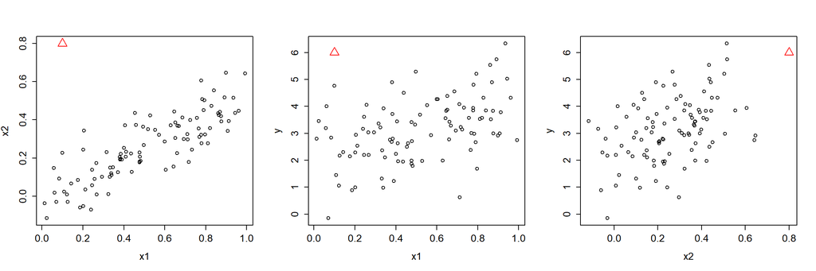

```r
clrsTmp <- c(rep(1,length(x1)-1),2)
old.par <- par(mfrow=c(1,3),ps=16)
plot(x1,x2,col=clrsTmp,pch=clrsTmp,cex=clrsTmp)
plot(x1,y,col=clrsTmp,pch=clrsTmp,cex=clrsTmp)
plot(x2,y,col=clrsTmp,pch=clrsTmp,cex=clrsTmp)
```

```r
par(old.par)
```

```r
# x1 and x2:
summary(lm(y~x1+x2))
```

```
##
## Call:
## lm(formula = y ~ x1 + x2)
##
## Residuals:
##      Min       1Q   Median       3Q      Max
## -2.73348 -0.69318 -0.05263  0.66385  2.30619
##
## Coefficients:
##             Estimate Std. Error t value Pr(>|t|)
## (Intercept)   2.2267     0.2314   9.624 7.91e-16 ***
## x1            0.5394     0.5922   0.911  0.36458
## x2            2.5146     0.8977   2.801  0.00614 **
## ---
## Signif. codes:  0 '***' 0.001 '**' 0.01 '*' 0.05 '.' 0.1 ' ' 1
##
## Residual standard error: 1.075 on 98 degrees of freedom
## Multiple R-squared:  0.2188, Adjusted R-squared:  0.2029
## F-statistic: 13.72 on 2 and 98 DF,  p-value: 5.564e-06
```

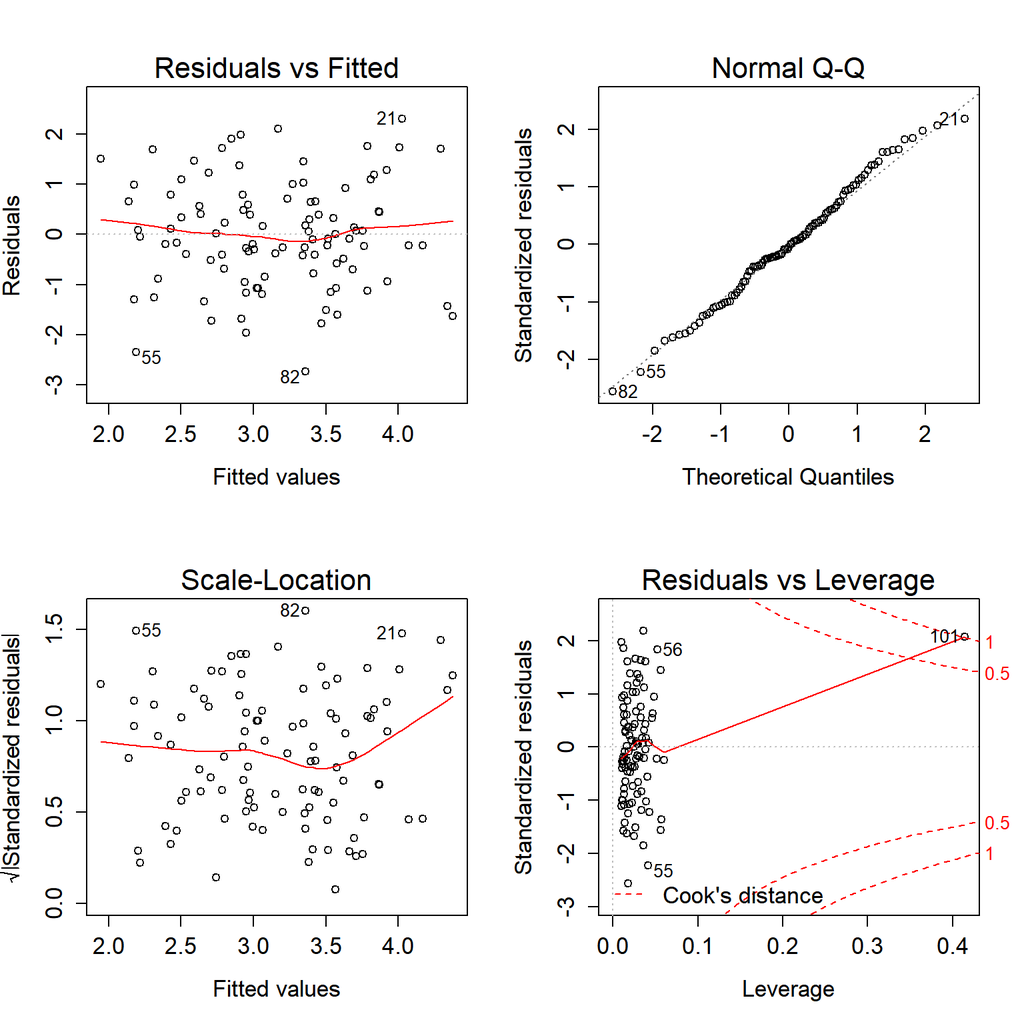

```r
old.par <- par(mfrow=c(2,2),ps=16)
plot(lm(y~x1+x2))
```

```r
par(old.par)
# just x1:
summary(lm(y~x1))
```

```
##
## Call:
## lm(formula = y ~ x1)
##
## Residuals:
##     Min      1Q  Median      3Q     Max
## -2.8897 -0.6556 -0.0909  0.5682  3.5665
##
## Coefficients:
##             Estimate Std. Error t value Pr(>|t|)
## (Intercept)   2.2569     0.2390   9.445 1.78e-15 ***
## x1            1.7657     0.4124   4.282 4.29e-05 ***
## ---
## Signif. codes:  0 '***' 0.001 '**' 0.01 '*' 0.05 '.' 0.1 ' ' 1
##
## Residual standard error: 1.111 on 99 degrees of freedom
## Multiple R-squared:  0.1562, Adjusted R-squared:  0.1477
## F-statistic: 18.33 on 1 and 99 DF,  p-value: 4.295e-05
```

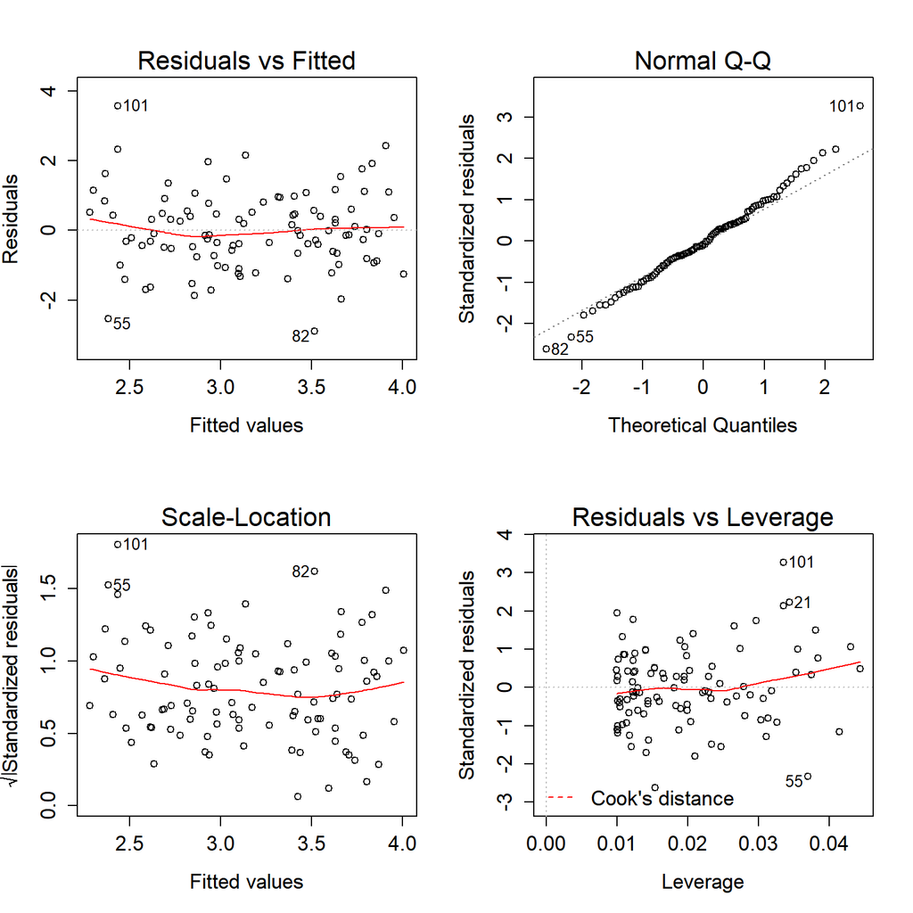

```r
old.par <- par(mfrow=c(2,2),ps=16)
plot(lm(y~x1))
```

```r
par(old.par)
# just x2:
summary(lm(y~x2))
```

```
##
## Call:
## lm(formula = y ~ x2)
##
## Residuals:
##      Min       1Q   Median       3Q      Max
## -2.64729 -0.71021 -0.06899  0.72699  2.38074
##
## Coefficients:
##             Estimate Std. Error t value Pr(>|t|)
## (Intercept)   2.3451     0.1912  12.264  < 2e-16 ***
## x2            3.1190     0.6040   5.164 1.25e-06 ***
## ---
## Signif. codes:  0 '***' 0.001 '**' 0.01 '*' 0.05 '.' 0.1 ' ' 1
##
## Residual standard error: 1.074 on 99 degrees of freedom
## Multiple R-squared:  0.2122, Adjusted R-squared:  0.2042
## F-statistic: 26.66 on 1 and 99 DF,  p-value: 1.253e-06
```

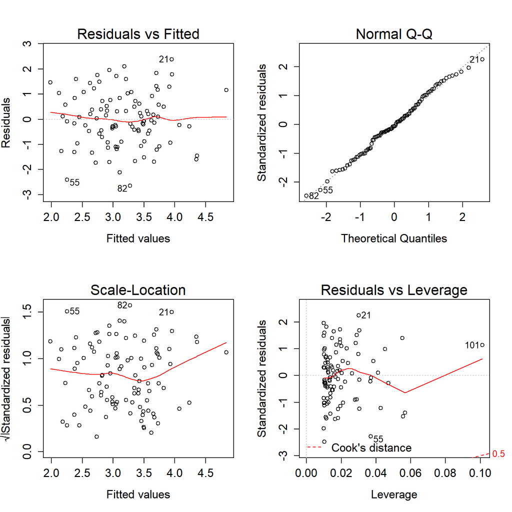

```r
old.par <- par(mfrow=c(2,2),ps=16)
plot(lm(y~x2))
```

```r
par(old.par)
```

## Ch.3.7, Exercise 11

“In this problem we will investigate the t-statistic for the null hypothesis H0 : $\beta = 0$ in simple linear regression without an intercept. To begin, we generate a predictor `x` and a response `y` as follows.”

```r
set.seed(10)
x=rnorm(100)
y=2*x+rnorm(100)
```

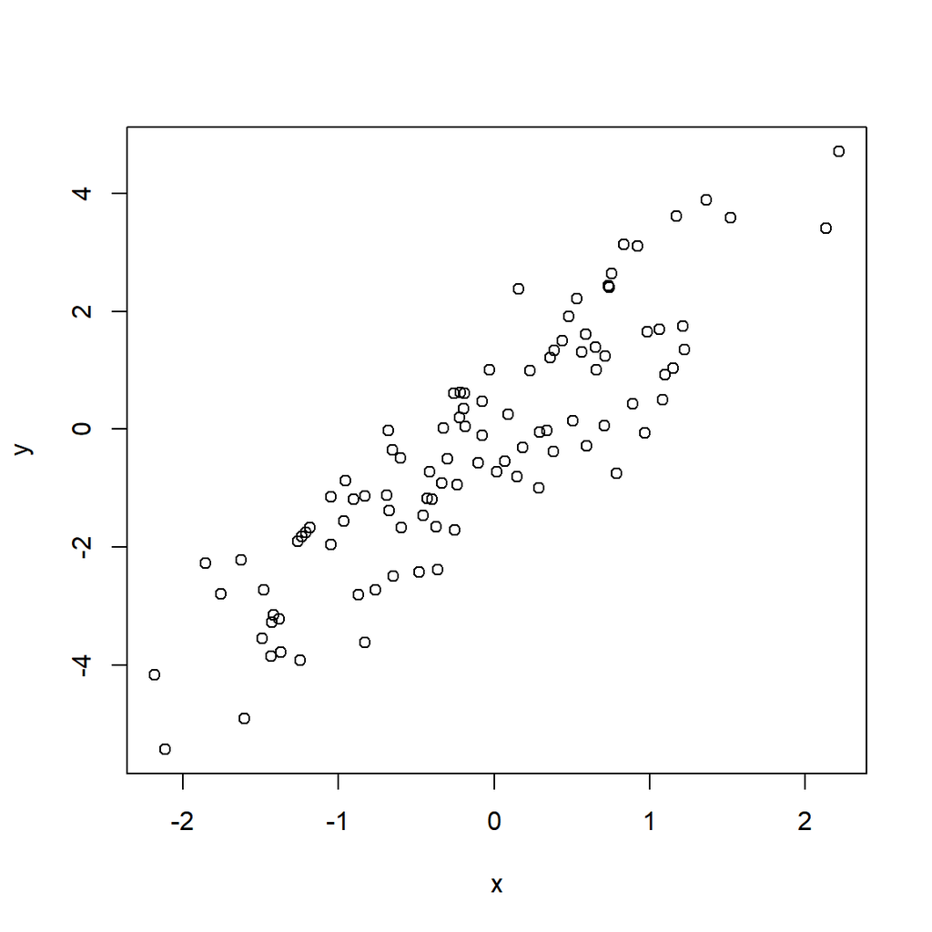

```r
plot(x,y)
```

“(a) Perform a simple linear regression of `y` onto `x`, without an intercept. Report the coefficient estimate $\hat{\beta}$, the standard error of this coefficient estimate, and the t-statistic and p-value associated with the null hypothesis H0 : $\beta = 0$. Comment on these results. (You can perform regression without an intercept using the command `lm(y~x+0)`.)”

```r
summary(lm(y~x+0))
```

```
##
## Call:
## lm(formula = y ~ x + 0)
##
## Residuals:
##      Min       1Q   Median       3Q      Max
## -2.28638 -0.86611  0.06209  0.63881  2.07521
##
## Coefficients:
##   Estimate Std. Error t value Pr(>|t|)
## x   1.9559     0.1028   19.02   <2e-16 ***
## ---
## Signif. codes:  0 '***' 0.001 '**' 0.01 '*' 0.05 '.' 0.1 ' ' 1
##
## Residual standard error: 0.9733 on 99 degrees of freedom
## Multiple R-squared:  0.7851, Adjusted R-squared:  0.783
## F-statistic: 361.8 on 1 and 99 DF,  p-value: < 2.2e-16
```

```r
summary(lm(y~x+0))$coefficients
```

```
##   Estimate Std. Error  t value    Pr(>|t|)
## x 1.955946  0.1028353 19.02018 7.87032e-35
```

“(b) Now perform a simple linear regression of `x` onto `y` without an intercept, and report the coefficient estimate, its standard error, and the corresponding t-statistic and p-values associated with the null hypothesis H0 : $\beta = 0$. Comment on these results.”

```r
summary(lm(x~y+0))
```

```
##
## Call:
## lm(formula = x ~ y + 0)
##
## Residuals:
##      Min       1Q   Median       3Q      Max
## -0.93922 -0.33296 -0.04355  0.32629  1.08673
##
## Coefficients:
##   Estimate Std. Error t value Pr(>|t|)
## y   0.4014     0.0211   19.02   <2e-16 ***
## ---
## Signif. codes:  0 '***' 0.001 '**' 0.01 '*' 0.05 '.' 0.1 ' ' 1
##
## Residual standard error: 0.4409 on 99 degrees of freedom
## Multiple R-squared:  0.7851, Adjusted R-squared:  0.783
## F-statistic: 361.8 on 1 and 99 DF,  p-value: < 2.2e-16
```

```r
summary(lm(x~y+0))$coefficients
```

```
##    Estimate Std. Error  t value    Pr(>|t|)
## y 0.4014124 0.02110456 19.02018 7.87032e-35
```

“(c) What is the relationship between the results obtained in (a) and (b)?”

“(d)-(e)” paper exercise

“(f) In R, show that when regression is performed with an intercept, the t-statistic for H0 : $\beta_1 = 0$ is the same for the regression of y onto x as it is for the regression of x onto y.”

```r
summary(lm(y~x))$coefficients
```

```
##               Estimate Std. Error   t value     Pr(>|t|)
## (Intercept) -0.1031248 0.09830464 -1.049033 2.967430e-01
## x            1.9402247 0.10386996 18.679362 4.641367e-34
```

```r
summary(lm(x~y))$coefficients
```

```
##               Estimate Std. Error    t value     Pr(>|t|)
## (Intercept) 0.01155371 0.04500375  0.2567277 7.979272e-01
## y           0.40238674 0.02154178 18.6793621 4.641367e-34
```

## Ch.3.7, Exercise 12

“This problem involves simple linear regression without an intercept.”

“(a) Recall that the coefficient estimate $\hat{\beta}$ for the linear regression of $Y$ onto $X$ without an intercept is given by (3.38). Under what circumstance is the coefficient estimate for the regression of $X$ onto $Y$ the same as the coefficient estimate for the regression of $Y$ onto $X$?”

“(b) Generate an example in R with $n = 100$ observations in which the coefficient estimate for the regression of $X$ onto $Y$ is different from the coefficient estimate for the regression of $Y$ onto $X$.”

```r
x <- rnorm(100)
y <- rnorm(100)
summary(lm(y~x+0))$coefficients
```

```
##       Estimate Std. Error     t value  Pr(>|t|)
## x -0.002889543  0.1094975 -0.02638913 0.9790001
```

```r
summary(lm(x~y+0))$coefficients
```

```
##       Estimate Std. Error     t value  Pr(>|t|)
## y -0.002434349 0.09224816 -0.02638913 0.9790001
```

“(c) Generate an example in R with $n = 100$ observations in which the coefficient estimate for the regression of X onto Y is the same as the coefficient estimate for the regression of $Y$ onto $X$.”

```r
y <- sample(x)
summary(lm(y~x+0))$coefficients
```

```
##      Estimate Std. Error    t value  Pr(>|t|)
## x -0.07429838   0.100226 -0.7413085 0.4602613
```

```r
summary(lm(x~y+0))$coefficients
```

```
##      Estimate Std. Error    t value  Pr(>|t|)
## y -0.07429838   0.100226 -0.7413085 0.4602613
```

A more subtle example:

```r
set.seed(1)
x <- rnorm(100)
y <- rnorm(length(x))
summary(lm(y~x+0))$coefficients
```

```
##       Estimate Std. Error     t value  Pr(>|t|)
## x -0.006123917  0.1064767 -0.05751413 0.9542516
```

```r
summary(lm(x~y+0))$coefficients
```

```
##       Estimate Std. Error     t value  Pr(>|t|)
## y -0.005455947 0.09486272 -0.05751413 0.9542516
```

```r
sum(y^2)
```

```
## [1] 90.97864
```

```r
sum(x^2)
```

```
## [1] 81.05509
```

```r
sum(y[-1]^2)
```

```
## [1] 90.59379
```

```r
sum(x[-1]^2)
```

```
## [1] 80.66265
```

```r
x[1] <- sqrt(sum(y^2)-sum(x[-1]^2))
x[1]
```

```
## [1] 3.211852
```

```r
summary(lm(y~x+0))$coefficients
```

```
##      Estimate Std. Error    t value  Pr(>|t|)
## x -0.03162865  0.1004535 -0.3148586 0.7535316
```

```r
summary(lm(x~y+0))$coefficients
```

```
##      Estimate Std. Error    t value  Pr(>|t|)
## y -0.03162865  0.1004535 -0.3148586 0.7535316
```

```r
x[1] <- -sqrt(sum(y^2)-sum(x[-1]^2))
x[1]
```

```
## [1] -3.211852
```

```r
summary(lm(y~x+0))$coefficients
```

```
##     Estimate Std. Error   t value  Pr(>|t|)
## x 0.01217341  0.1004963 0.1211329 0.9038313
```

```r
summary(lm(x~y+0))$coefficients
```

```
##     Estimate Std. Error   t value  Pr(>|t|)
## y 0.01217341  0.1004963 0.1211329 0.9038313
```

## Ch.3.7, Exercise 15

This problem involves the Boston data set, which we saw in the lab for this chapter. We will now try to predict per capita crime rate using the other variables in this data set. In other words, per capita crime rate is the response, and the other variables are the predictors.

```r
library(MASS)
class(Boston)
```

```
## [1] "data.frame"
```

```r
dim(Boston)
```

```
## [1] 506  14
```

```r
head(Boston)
```

```
##      crim zn indus chas   nox    rm  age    dis rad tax ptratio  black
## 1 0.00632 18  2.31    0 0.538 6.575 65.2 4.0900   1 296    15.3 396.90
## 2 0.02731  0  7.07    0 0.469 6.421 78.9 4.9671   2 242    17.8 396.90
## 3 0.02729  0  7.07    0 0.469 7.185 61.1 4.9671   2 242    17.8 392.83
## 4 0.03237  0  2.18    0 0.458 6.998 45.8 6.0622   3 222    18.7 394.63
## 5 0.06905  0  2.18    0 0.458 7.147 54.2 6.0622   3 222    18.7 396.90
## 6 0.02985  0  2.18    0 0.458 6.430 58.7 6.0622   3 222    18.7 394.12
##   lstat medv
## 1  4.98 24.0
## 2  9.14 21.6
## 3  4.03 34.7
## 4  2.94 33.4
## 5  5.33 36.2
## 6  5.21 28.7
```

```r
summary(Boston)
```

```
##       crim                zn             indus            chas
##  Min.   : 0.00632   Min.   :  0.00   Min.   : 0.46   Min.   :0.00000
##  1st Qu.: 0.08204   1st Qu.:  0.00   1st Qu.: 5.19   1st Qu.:0.00000
##  Median : 0.25651   Median :  0.00   Median : 9.69   Median :0.00000
##  Mean   : 3.61352   Mean   : 11.36   Mean   :11.14   Mean   :0.06917
##  3rd Qu.: 3.67708   3rd Qu.: 12.50   3rd Qu.:18.10   3rd Qu.:0.00000
##  Max.   :88.97620   Max.   :100.00   Max.   :27.74   Max.   :1.00000
##       nox               rm             age              dis
##  Min.   :0.3850   Min.   :3.561   Min.   :  2.90   Min.   : 1.130
##  1st Qu.:0.4490   1st Qu.:5.886   1st Qu.: 45.02   1st Qu.: 2.100
##  Median :0.5380   Median :6.208   Median : 77.50   Median : 3.207
##  Mean   :0.5547   Mean   :6.285   Mean   : 68.57   Mean   : 3.795
##  3rd Qu.:0.6240   3rd Qu.:6.623   3rd Qu.: 94.08   3rd Qu.: 5.188
##  Max.   :0.8710   Max.   :8.780   Max.   :100.00   Max.   :12.127
##       rad              tax           ptratio          black
##  Min.   : 1.000   Min.   :187.0   Min.   :12.60   Min.   :  0.32
##  1st Qu.: 4.000   1st Qu.:279.0   1st Qu.:17.40   1st Qu.:375.38
##  Median : 5.000   Median :330.0   Median :19.05   Median :391.44
##  Mean   : 9.549   Mean   :408.2   Mean   :18.46   Mean   :356.67
##  3rd Qu.:24.000   3rd Qu.:666.0   3rd Qu.:20.20   3rd Qu.:396.23
##  Max.   :24.000   Max.   :711.0   Max.   :22.00   Max.   :396.90
##      lstat            medv
##  Min.   : 1.73   Min.   : 5.00
##  1st Qu.: 6.95   1st Qu.:17.02
##  Median :11.36   Median :21.20
##  Mean   :12.65   Mean   :22.53
##  3rd Qu.:16.95   3rd Qu.:25.00
##  Max.   :37.97   Max.   :50.00
```

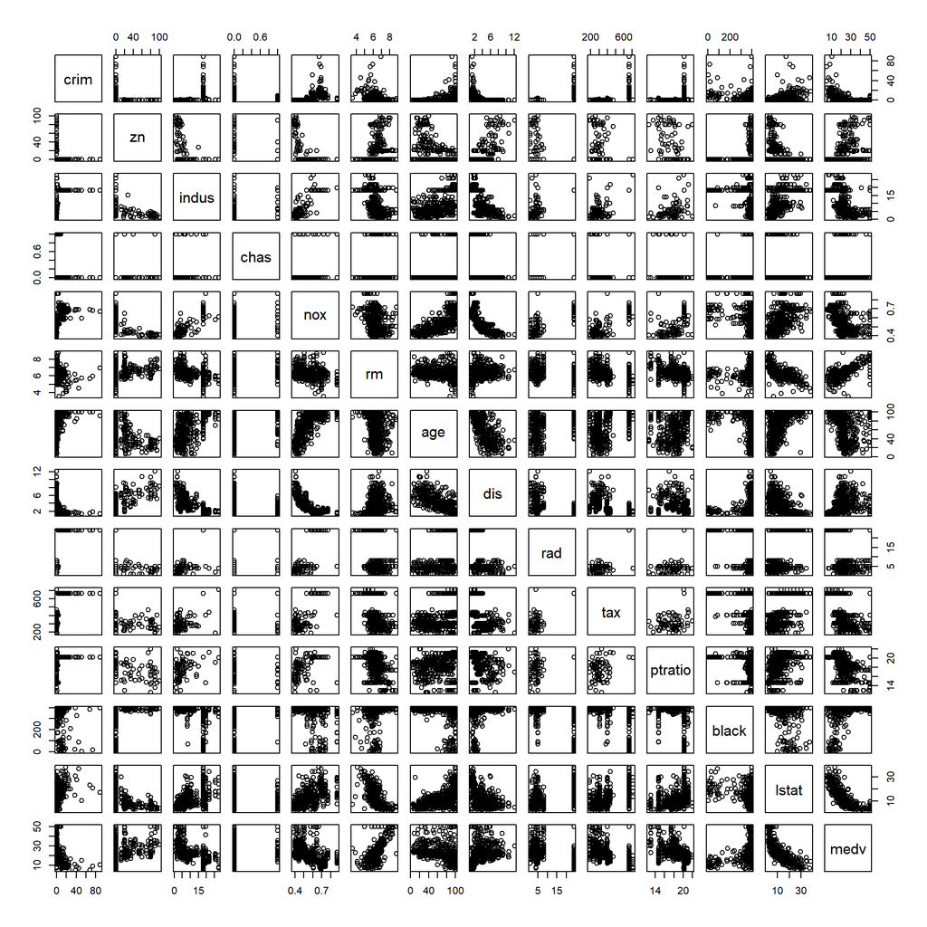

```r
pairs(Boston)
```

1. For each predictor, fit a simple linear regression model to predict the response. Describe your results. In which of the models is there a statistically significant association between the predictor and the response? Create some plots to back up your assertions.

```
## zn
##
## Call:
## lm(formula = crim ~ ., data = Boston[, c(1, iTmp)])
##
## Residuals:
##    Min     1Q Median     3Q    Max
## -4.429 -4.222 -2.620  1.250 84.523
##
## Coefficients:
##             Estimate Std. Error t value Pr(>|t|)
## (Intercept)  4.45369    0.41722  10.675  < 2e-16 ***
## zn          -0.07393    0.01609  -4.594 5.51e-06 ***
## ---
## Signif. codes:  0 '***' 0.001 '**' 0.01 '*' 0.05 '.' 0.1 ' ' 1
##
## Residual standard error: 8.435 on 504 degrees of freedom
## Multiple R-squared:  0.04019,    Adjusted R-squared:  0.03828
## F-statistic:  21.1 on 1 and 504 DF,  p-value: 5.506e-06
```

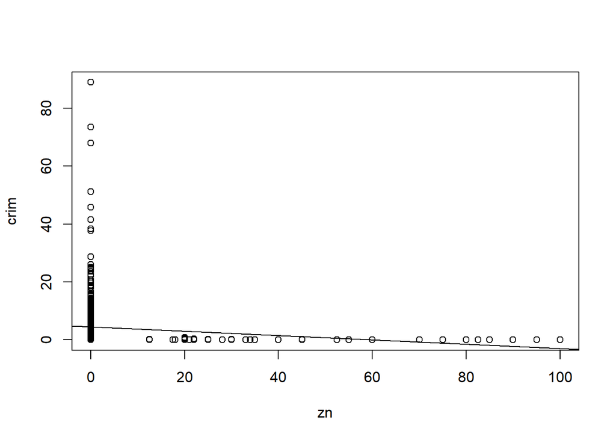

```
## indus
##
## Call:
## lm(formula = crim ~ ., data = Boston[, c(1, iTmp)])
##
## Residuals:
##     Min      1Q  Median      3Q     Max
## -11.972  -2.698  -0.736   0.712  81.813
##
## Coefficients:
##             Estimate Std. Error t value Pr(>|t|)
## (Intercept) -2.06374    0.66723  -3.093  0.00209 **
## indus        0.50978    0.05102   9.991  < 2e-16 ***
## ---
## Signif. codes:  0 '***' 0.001 '**' 0.01 '*' 0.05 '.' 0.1 ' ' 1
##
## Residual standard error: 7.866 on 504 degrees of freedom
## Multiple R-squared:  0.1653, Adjusted R-squared:  0.1637
## F-statistic: 99.82 on 1 and 504 DF,  p-value: < 2.2e-16
```

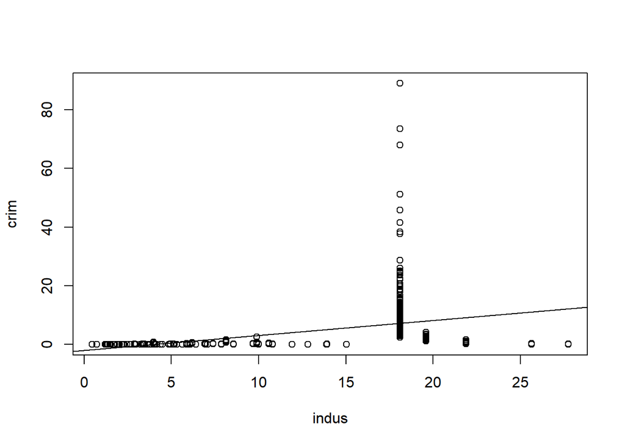

```
## chas
##
## Call:
## lm(formula = crim ~ ., data = Boston[, c(1, iTmp)])
##
## Residuals:
##    Min     1Q Median     3Q    Max
## -3.738 -3.661 -3.435  0.018 85.232
##
## Coefficients:
##             Estimate Std. Error t value Pr(>|t|)
## (Intercept)   3.7444     0.3961   9.453   <2e-16 ***
## chas         -1.8928     1.5061  -1.257    0.209
## ---
## Signif. codes:  0 '***' 0.001 '**' 0.01 '*' 0.05 '.' 0.1 ' ' 1
##
## Residual standard error: 8.597 on 504 degrees of freedom
## Multiple R-squared:  0.003124,   Adjusted R-squared:  0.001146
## F-statistic: 1.579 on 1 and 504 DF,  p-value: 0.2094
```

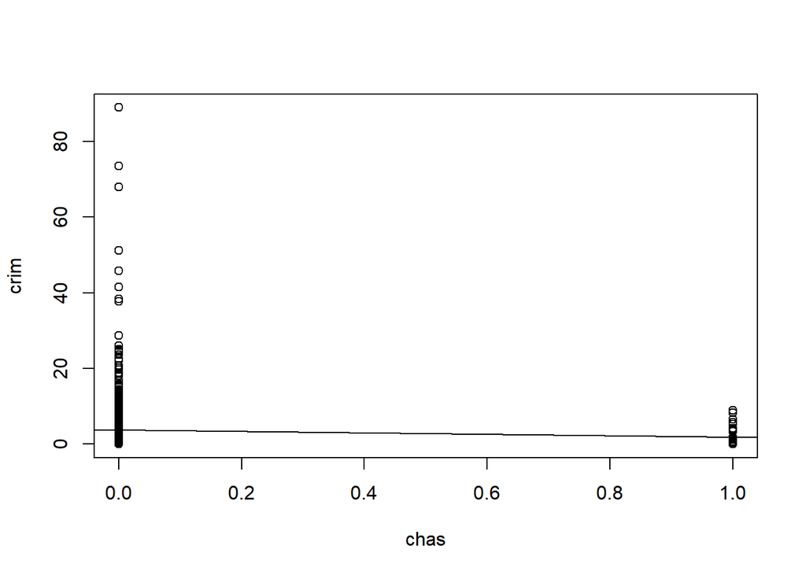

```
## nox
##
## Call:
## lm(formula = crim ~ ., data = Boston[, c(1, iTmp)])
##
## Residuals:
##     Min      1Q  Median      3Q     Max
## -12.371  -2.738  -0.974   0.559  81.728
##
## Coefficients:
##             Estimate Std. Error t value Pr(>|t|)
## (Intercept)  -13.720      1.699  -8.073 5.08e-15 ***
## nox           31.249      2.999  10.419  < 2e-16 ***
## ---
## Signif. codes:  0 '***' 0.001 '**' 0.01 '*' 0.05 '.' 0.1 ' ' 1
##
## Residual standard error: 7.81 on 504 degrees of freedom
## Multiple R-squared:  0.1772, Adjusted R-squared:  0.1756
## F-statistic: 108.6 on 1 and 504 DF,  p-value: < 2.2e-16
```

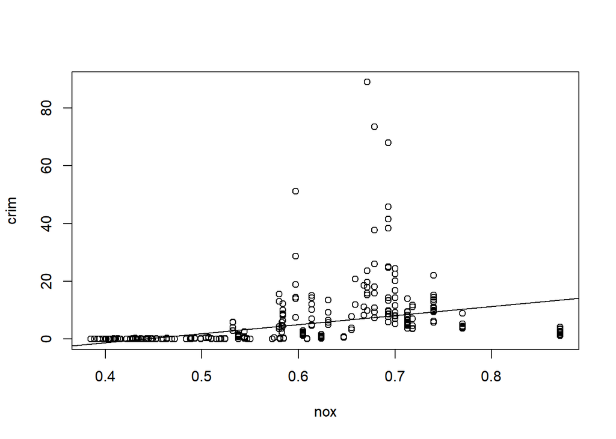

```
## rm
##
## Call:
## lm(formula = crim ~ ., data = Boston[, c(1, iTmp)])
##
## Residuals:
##    Min     1Q Median     3Q    Max
## -6.604 -3.952 -2.654  0.989 87.197
##
## Coefficients:
##             Estimate Std. Error t value Pr(>|t|)
## (Intercept)   20.482      3.365   6.088 2.27e-09 ***
## rm            -2.684      0.532  -5.045 6.35e-07 ***
## ---
## Signif. codes:  0 '***' 0.001 '**' 0.01 '*' 0.05 '.' 0.1 ' ' 1
##
## Residual standard error: 8.401 on 504 degrees of freedom
## Multiple R-squared:  0.04807,    Adjusted R-squared:  0.04618
## F-statistic: 25.45 on 1 and 504 DF,  p-value: 6.347e-07
```

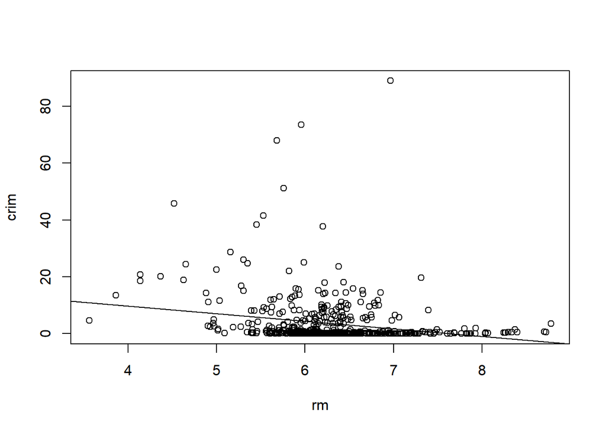

```
## age
##
## Call:
## lm(formula = crim ~ ., data = Boston[, c(1, iTmp)])
##
## Residuals:
##    Min     1Q Median     3Q    Max
## -6.789 -4.257 -1.230  1.527 82.849
##
## Coefficients:
##             Estimate Std. Error t value Pr(>|t|)
## (Intercept) -3.77791    0.94398  -4.002 7.22e-05 ***
## age          0.10779    0.01274   8.463 2.85e-16 ***
## ---
## Signif. codes:  0 '***' 0.001 '**' 0.01 '*' 0.05 '.' 0.1 ' ' 1
##
## Residual standard error: 8.057 on 504 degrees of freedom
## Multiple R-squared:  0.1244, Adjusted R-squared:  0.1227
## F-statistic: 71.62 on 1 and 504 DF,  p-value: 2.855e-16
```

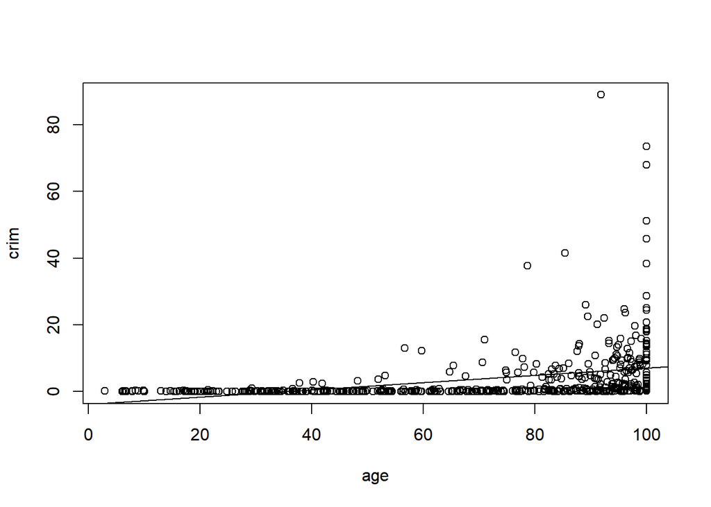

```
## dis
##
## Call:
## lm(formula = crim ~ ., data = Boston[, c(1, iTmp)])
##
## Residuals:
##    Min     1Q Median     3Q    Max
## -6.708 -4.134 -1.527  1.516 81.674
##
## Coefficients:
##             Estimate Std. Error t value Pr(>|t|)
## (Intercept)   9.4993     0.7304  13.006   <2e-16 ***
## dis          -1.5509     0.1683  -9.213   <2e-16 ***
## ---
## Signif. codes:  0 '***' 0.001 '**' 0.01 '*' 0.05 '.' 0.1 ' ' 1
##
## Residual standard error: 7.965 on 504 degrees of freedom
## Multiple R-squared:  0.1441, Adjusted R-squared:  0.1425
## F-statistic: 84.89 on 1 and 504 DF,  p-value: < 2.2e-16
```

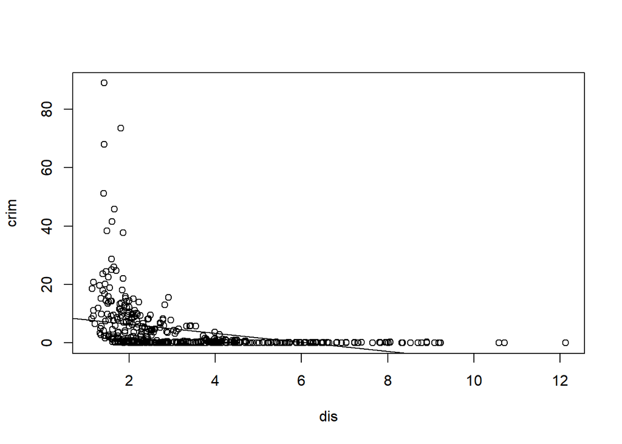

```
## rad
##
## Call:
## lm(formula = crim ~ ., data = Boston[, c(1, iTmp)])
##
## Residuals:
##     Min      1Q  Median      3Q     Max
## -10.164  -1.381  -0.141   0.660  76.433
##
## Coefficients:
##             Estimate Std. Error t value Pr(>|t|)
## (Intercept) -2.28716    0.44348  -5.157 3.61e-07 ***
## rad          0.61791    0.03433  17.998  < 2e-16 ***
## ---
## Signif. codes:  0 '***' 0.001 '**' 0.01 '*' 0.05 '.' 0.1 ' ' 1
##
## Residual standard error: 6.718 on 504 degrees of freedom
## Multiple R-squared:  0.3913, Adjusted R-squared:   0.39
## F-statistic: 323.9 on 1 and 504 DF,  p-value: < 2.2e-16
```

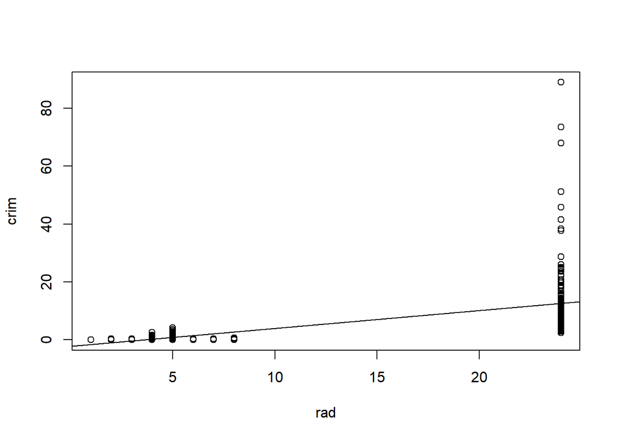

```
## tax
##
## Call:
## lm(formula = crim ~ ., data = Boston[, c(1, iTmp)])
##
## Residuals:
##     Min      1Q  Median      3Q     Max
## -12.513  -2.738  -0.194   1.065  77.696
##
## Coefficients:
##              Estimate Std. Error t value Pr(>|t|)
## (Intercept) -8.528369   0.815809  -10.45   <2e-16 ***
## tax          0.029742   0.001847   16.10   <2e-16 ***
## ---
## Signif. codes:  0 '***' 0.001 '**' 0.01 '*' 0.05 '.' 0.1 ' ' 1
##
## Residual standard error: 6.997 on 504 degrees of freedom
## Multiple R-squared:  0.3396, Adjusted R-squared:  0.3383
## F-statistic: 259.2 on 1 and 504 DF,  p-value: < 2.2e-16
```

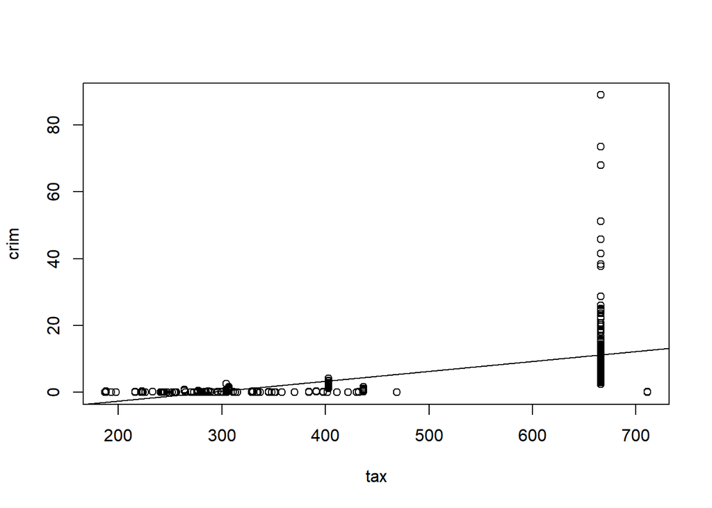

```
## ptratio
##
## Call:
## lm(formula = crim ~ ., data = Boston[, c(1, iTmp)])
##
## Residuals:
##    Min     1Q Median     3Q    Max
## -7.654 -3.985 -1.912  1.825 83.353
##
## Coefficients:
##             Estimate Std. Error t value Pr(>|t|)
## (Intercept) -17.6469     3.1473  -5.607 3.40e-08 ***
## ptratio       1.1520     0.1694   6.801 2.94e-11 ***
## ---
## Signif. codes:  0 '***' 0.001 '**' 0.01 '*' 0.05 '.' 0.1 ' ' 1
##
## Residual standard error: 8.24 on 504 degrees of freedom
## Multiple R-squared:  0.08407,    Adjusted R-squared:  0.08225
## F-statistic: 46.26 on 1 and 504 DF,  p-value: 2.943e-11
```

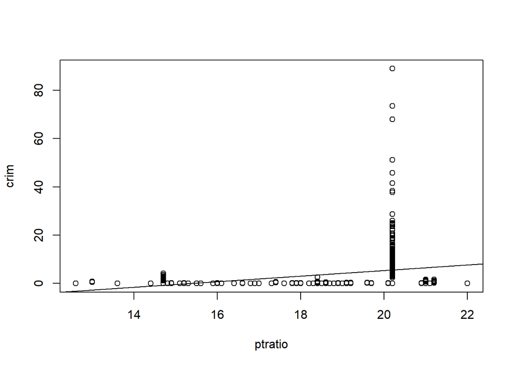

```
## black
##
## Call:
## lm(formula = crim ~ ., data = Boston[, c(1, iTmp)])
##
## Residuals:
##     Min      1Q  Median      3Q     Max
## -13.756  -2.299  -2.095  -1.296  86.822
##
## Coefficients:
##              Estimate Std. Error t value Pr(>|t|)
## (Intercept) 16.553529   1.425903  11.609   <2e-16 ***
## black       -0.036280   0.003873  -9.367   <2e-16 ***
## ---
## Signif. codes:  0 '***' 0.001 '**' 0.01 '*' 0.05 '.' 0.1 ' ' 1
##
## Residual standard error: 7.946 on 504 degrees of freedom
## Multiple R-squared:  0.1483, Adjusted R-squared:  0.1466
## F-statistic: 87.74 on 1 and 504 DF,  p-value: < 2.2e-16
```

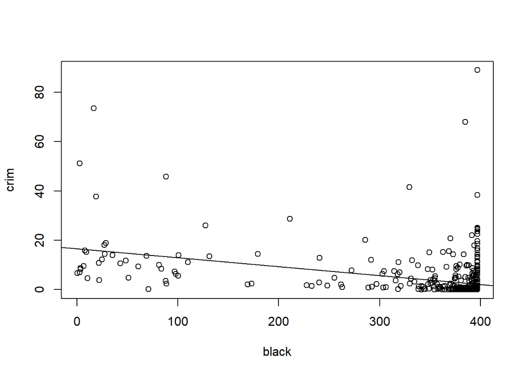

```
## lstat
##
## Call:
## lm(formula = crim ~ ., data = Boston[, c(1, iTmp)])
##
## Residuals:
##     Min      1Q  Median      3Q     Max
## -13.925  -2.822  -0.664   1.079  82.862
##
## Coefficients:
##             Estimate Std. Error t value Pr(>|t|)
## (Intercept) -3.33054    0.69376  -4.801 2.09e-06 ***
## lstat        0.54880    0.04776  11.491  < 2e-16 ***
## ---
## Signif. codes:  0 '***' 0.001 '**' 0.01 '*' 0.05 '.' 0.1 ' ' 1
##
## Residual standard error: 7.664 on 504 degrees of freedom
## Multiple R-squared:  0.2076, Adjusted R-squared:  0.206
## F-statistic:   132 on 1 and 504 DF,  p-value: < 2.2e-16
```

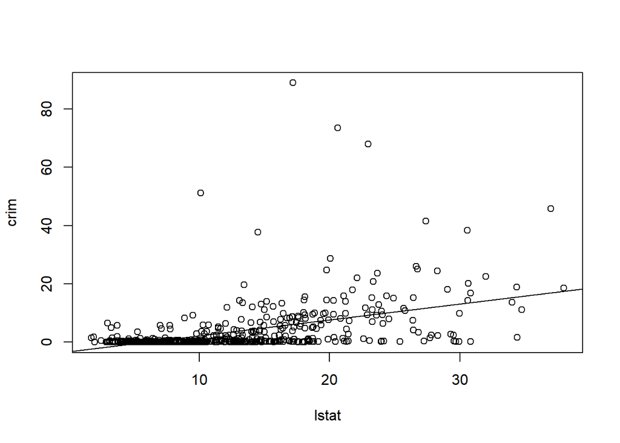

```
## medv
##
## Call:
## lm(formula = crim ~ ., data = Boston[, c(1, iTmp)])
##
## Residuals:
##    Min     1Q Median     3Q    Max
## -9.071 -4.022 -2.343  1.298 80.957
##
## Coefficients:
##             Estimate Std. Error t value Pr(>|t|)
## (Intercept) 11.79654    0.93419   12.63   <2e-16 ***
## medv        -0.36316    0.03839   -9.46   <2e-16 ***
## ---
## Signif. codes:  0 '***' 0.001 '**' 0.01 '*' 0.05 '.' 0.1 ' ' 1
##
## Residual standard error: 7.934 on 504 degrees of freedom
## Multiple R-squared:  0.1508, Adjusted R-squared:  0.1491
## F-statistic: 89.49 on 1 and 504 DF,  p-value: < 2.2e-16
```

[1 more figures not shown]

```r
tmp1Dcoefs <- NULL
tmpNms <- NULL
for ( iTmp in 2:dim(Boston)[2] ) {
  cat(colnames(Boston)[iTmp],fill=TRUE)
  lmTmp <- lm(crim~.,Boston[,c(1,iTmp)])
  tmp1Dcoefs <- c(tmp1Dcoefs,coef(lmTmp)[2])
  tmpNms <- c(tmpNms,colnames(Boston)[iTmp])
  print(summary(lmTmp))
  plot(Boston[,c(iTmp,1)])
  abline(lm(crim~.,Boston[,c(1,iTmp)]))
}
```

```r
names(tmp1Dcoefs) <- tmpNms
```

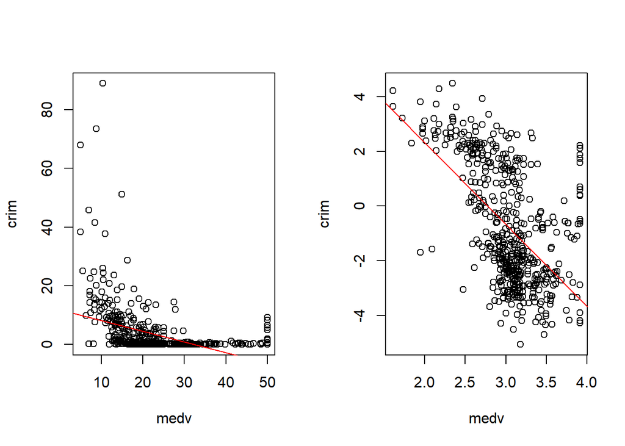

```r
# crim~medv:
old.par <- par(mfrow=c(1,2))
plot(Boston[,c(dim(Boston)[2],1)])
abline(lm(crim~medv,Boston),col=2)
plot(log(Boston[,c(dim(Boston)[2],1)]))
abline(lm(log(crim)~log(medv),Boston),col=2)
```

```r
par(old.par)
summary(lm(log(crim)~log(medv),Boston))
```

```
##
## Call:
## lm(formula = log(crim) ~ log(medv), data = Boston)
##
## Residuals:
##    Min     1Q Median     3Q    Max
## -4.182 -1.337 -0.293  1.417  5.636
##
## Coefficients:
##             Estimate Std. Error t value Pr(>|t|)
## (Intercept)   8.3241     0.5941   14.01   <2e-16 ***
## log(medv)    -3.0003     0.1940  -15.46   <2e-16 ***
## ---
## Signif. codes:  0 '***' 0.001 '**' 0.01 '*' 0.05 '.' 0.1 ' ' 1
##
## Residual standard error: 1.782 on 504 degrees of freedom
## Multiple R-squared:  0.3218, Adjusted R-squared:  0.3204
## F-statistic: 239.1 on 1 and 504 DF,  p-value: < 2.2e-16
```

```r
summary(lm(crim~medv,Boston))
```

```
##
## Call:
## lm(formula = crim ~ medv, data = Boston)
##
## Residuals:
##    Min     1Q Median     3Q    Max
## -9.071 -4.022 -2.343  1.298 80.957
##
## Coefficients:
##             Estimate Std. Error t value Pr(>|t|)
## (Intercept) 11.79654    0.93419   12.63   <2e-16 ***
## medv        -0.36316    0.03839   -9.46   <2e-16 ***
## ---
## Signif. codes:  0 '***' 0.001 '**' 0.01 '*' 0.05 '.' 0.1 ' ' 1
##
## Residual standard error: 7.934 on 504 degrees of freedom
## Multiple R-squared:  0.1508, Adjusted R-squared:  0.1491
## F-statistic: 89.49 on 1 and 504 DF,  p-value: < 2.2e-16
```

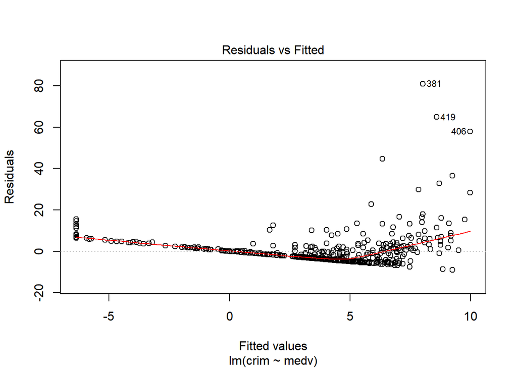

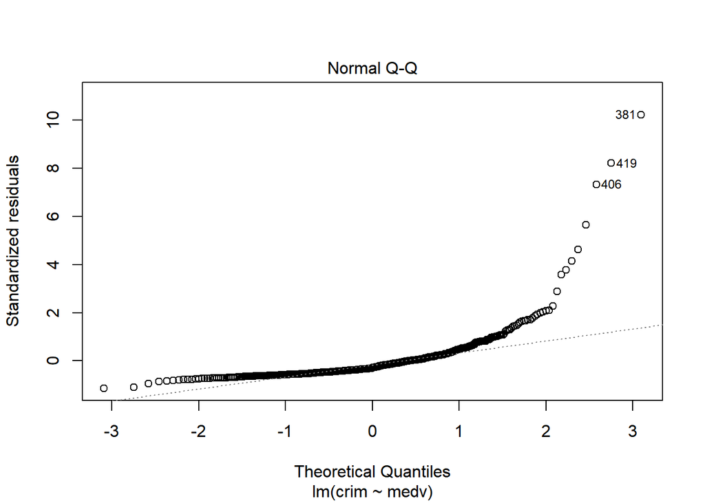

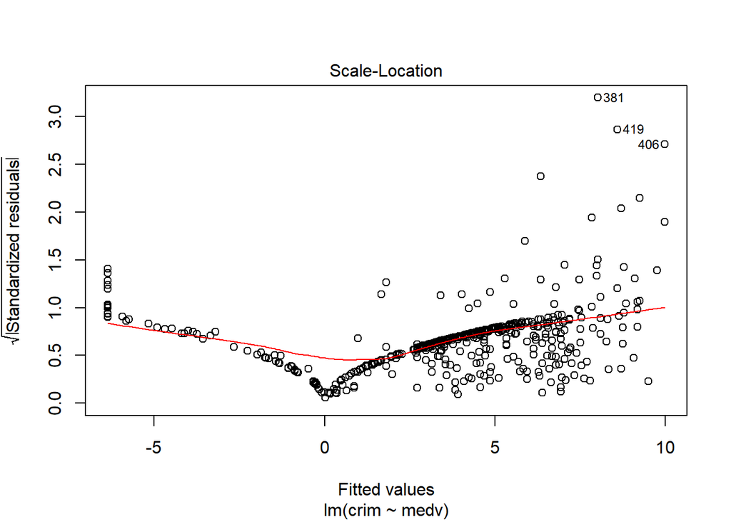

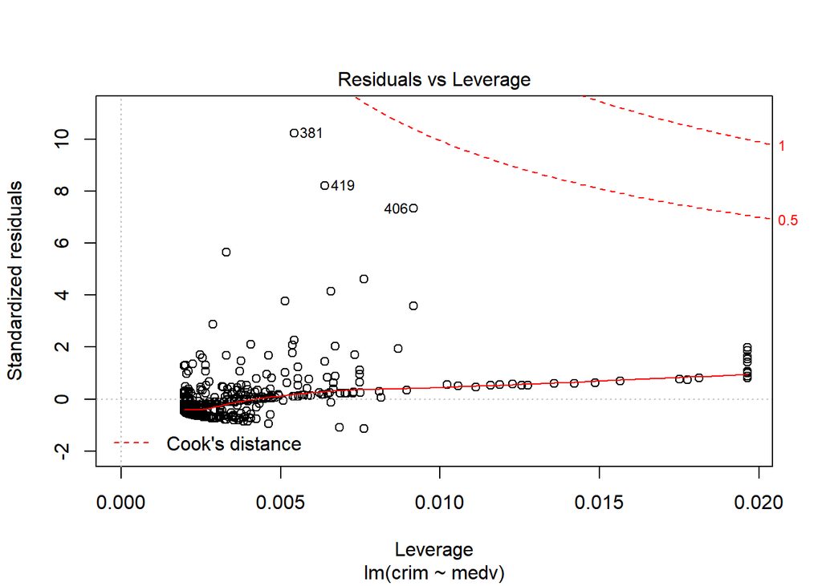

```r
plot(lm(crim~medv,Boston))
```

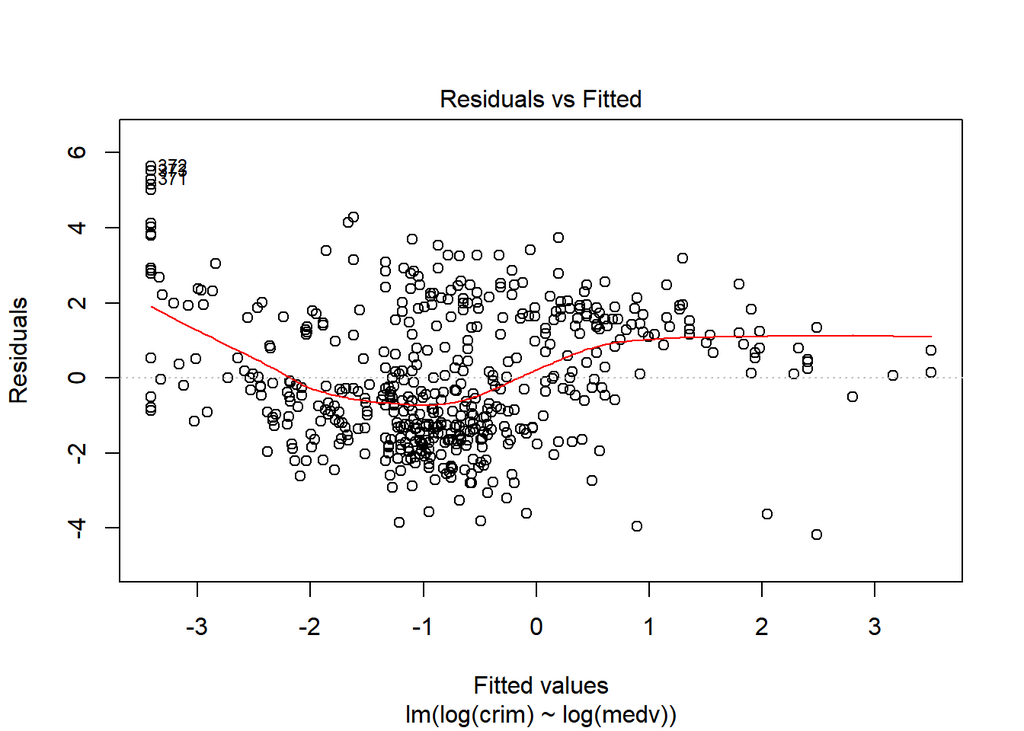

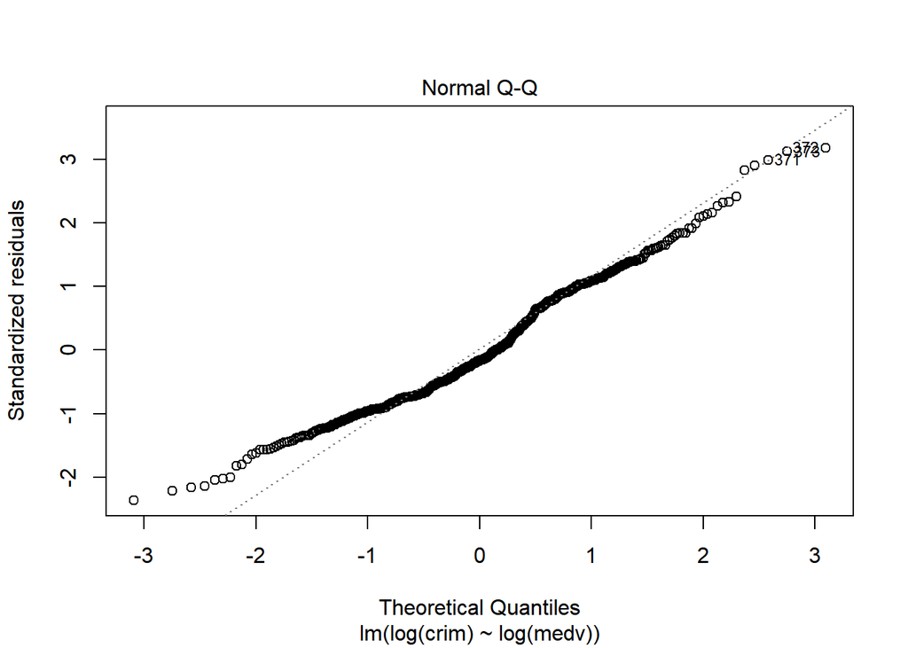

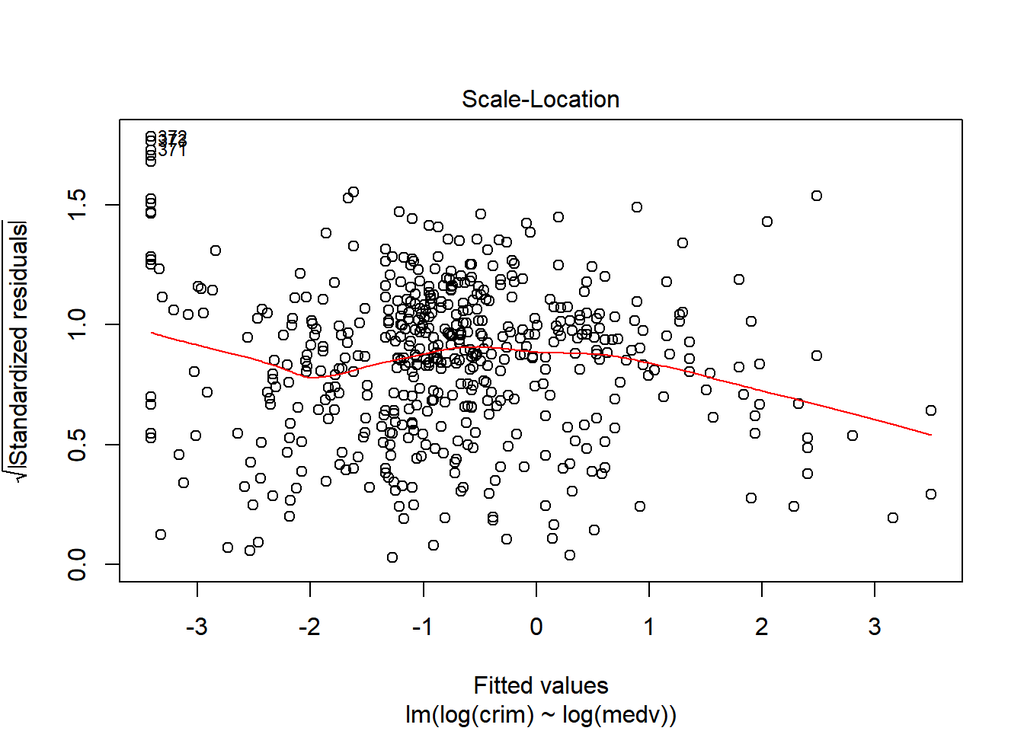

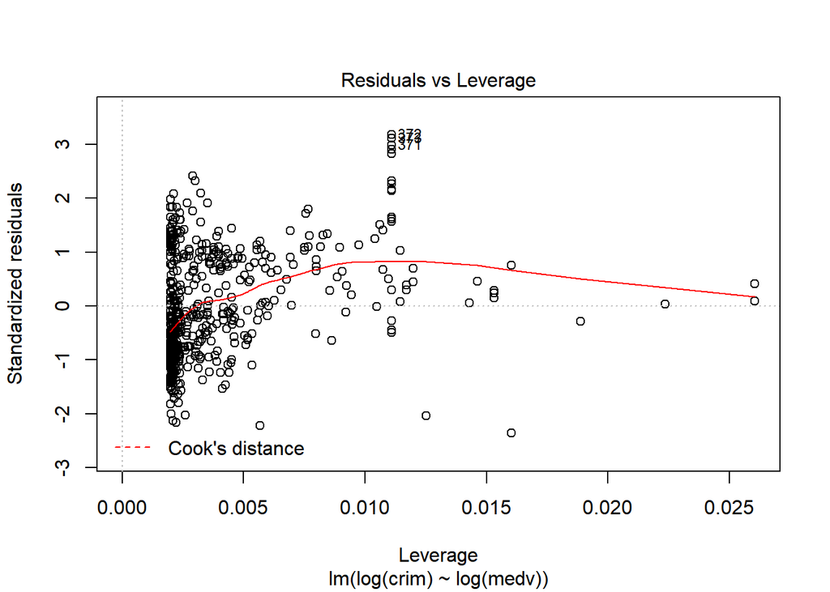

```r
plot(lm(log(crim)~log(medv),Boston))
```

2. Fit a multiple regression model to predict the response using all of the predictors. Describe your results. For which predictors can we reject the null hypothesis H0 : $\beta_j = 0$?

```r
# all variables:
summary(lm(crim~.,Boston))
```

```
##
## Call:
## lm(formula = crim ~ ., data = Boston)
##
## Residuals:
##    Min     1Q Median     3Q    Max
## -9.924 -2.120 -0.353  1.019 75.051
##
## Coefficients:
##               Estimate Std. Error t value Pr(>|t|)
## (Intercept)  17.033228   7.234903   2.354 0.018949 *
## zn            0.044855   0.018734   2.394 0.017025 *
## indus        -0.063855   0.083407  -0.766 0.444294
## chas         -0.749134   1.180147  -0.635 0.525867
## nox         -10.313535   5.275536  -1.955 0.051152 .
## rm            0.430131   0.612830   0.702 0.483089
## age           0.001452   0.017925   0.081 0.935488
## dis          -0.987176   0.281817  -3.503 0.000502 ***
## rad           0.588209   0.088049   6.680 6.46e-11 ***
## tax          -0.003780   0.005156  -0.733 0.463793
## ptratio      -0.271081   0.186450  -1.454 0.146611
## black        -0.007538   0.003673  -2.052 0.040702 *
## lstat         0.126211   0.075725   1.667 0.096208 .
## medv         -0.198887   0.060516  -3.287 0.001087 **
## ---
## Signif. codes:  0 '***' 0.001 '**' 0.01 '*' 0.05 '.' 0.1 ' ' 1
##
## Residual standard error: 6.439 on 492 degrees of freedom
## Multiple R-squared:  0.454,  Adjusted R-squared:  0.4396
## F-statistic: 31.47 on 13 and 492 DF,  p-value: < 2.2e-16
```